# EasyVisa Project

## Will tuning the hyperparameters improve the model performance?

### Hyperparameter Tuning - Decision Tree

```python
# Choose the type of classifier.
dTree_estimator = DecisionTreeClassifier(class_weight="balanced", random_state=1)

# Grid of parameters to choose from
parameters = {
    "max_depth": np.arange(5, 16, 5),
    "min_samples_leaf": [3, 5, 7],
    "max_leaf_nodes": [2, 5],
    "min_impurity_decrease": [0.0001, 0.001],
}

# Type of scoring used to compare parameter combinations
scorer = metrics.make_scorer(metrics.f1_score)

# to run grid search with n_jobs = -1 and cv=5
grid_obj = GridSearchCV (dTree_estimator , parameters, scoring=scorer, cv=5, n_jobs=-1)

# to fit the grid_obj on the train data
grid_obj = grid_obj.fit(X_train, y_train)

# Set the clf to the best combination of parameters
dTree_estimator = grid_obj.best_estimator_

# Fit the best algorithm to the data.
dTree_estimator.fit(X_train, y_train)
```

```
DecisionTreeClassifier(class_weight='balanced', max_depth=5, max_leaf_nodes=2,
                       min_impurity_decrease=0.0001, min_samples_leaf=3,
                       random_state=1)
```

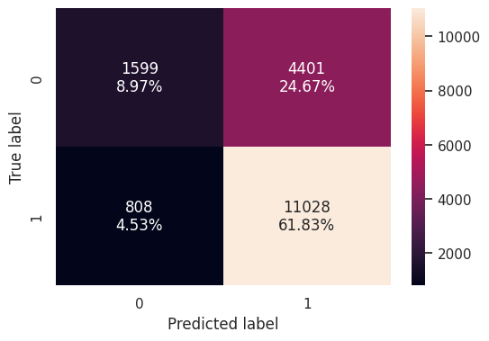

```python
# confusion matrix for training data (tuned)
confusion_matrix_sklearn(dTree_estimator, X_train, y_train)
```

- True Positives (TP): 11,028 (61.83%)
  - Model predicted the right certified candidates for 61.83% of the data.
- False Negatives (FN): 808 (4.53%)
  - Model predicted denied candidates when the candidate was certified for 4.53% of the data.
- False Positives (FP): 4,401 (24.67%)
  - Model predicted the candidate would be certified when they were denied for 24.67% of the data.
- True Negatives (TN): 1,599 (8.97%)
  - Model predicted the candidate would be denied when they were actually denied for 8.97% of the data.
- Model was able to predict 70.8% of the data into the appropriate classification.

```python
# to check performance on training set (tuned)
decision_tree_tune_perf_train = model_performance_classification_sklearn(dTree_estimator, X_train, y_train)
decision_tree_tune_perf_train
```

|  | Accuracy | Recall | Precision | F1 |
| --- | --- | --- | --- | --- |
| 0 | 0.70795 | 0.93173 | 0.71476 | 0.80895 |

- Decision Tree Train Performance (tuned):
  - Accuracy: 70.80%
  - Recall: 93.17%
  - Precision: 71.48%
  - F1: 80.90%

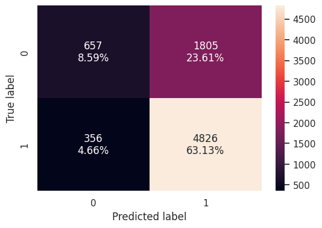

```python
# confusion matrix for testing data (tuned)
confusion_matrix_sklearn(dTree_estimator, X_test, y_test)
```

- True Positives (TP): 4,826 (63.13%)
  - Model predicted the right certified candidates for 63.13% of the data.
- False Negatives (FN): 356 (4.66%)
  - Model predicted denied candidates when the candidate was certified for 4.66% of the data.
- False Positives (FP): 1,805 (23.61%)
  - Model predicted the candidate would be certified when they were denied for 23.61% of the data.
- True Negatives (TN): 657 (8.59%)
  - Model predicted the candidate would be denied when they were actually denied for 8.59% of the data.
- Model was able to predict 71.72% of the data into the appropriate classification.

```python
# to check performance for testing data (tuned)
dtree_estimator_model_test_perf = model_performance_classification_sklearn(dTree_estimator, X_test, y_test)
dtree_estimator_model_test_perf
```

|  | Accuracy | Recall | Precision | F1 |
| --- | --- | --- | --- | --- |
| 0 | 0.71729 | 0.93130 | 0.72779 | 0.81707 |

- Decision Tree Test Performance (tuned):
  - Accuracy: 71.73%
  - Recall: 93.13%
  - Precision: 72.78%
  - F1: 81.71%
- Performance data for test data may be reliable. Further exploration is needed.